# Analysis of general effects for Neural Measures | Posner+SSVEP paradigm

[Christopher Gundlach](https://www.researchgate.net/profile/Christopher_Gundlach)

2024-08-26

# Initialisierung

**Setting up R libraries**

# Analysis of electrophysiological data (Posner Paradigma)

## subaveraged Daten werden geladen

Loading data C:/Users/psy05cvd/Dropbox/work/R-statistics/experiments/ssvep_posnalpha_behave/data_in/Behavior_FFT_singletrials_cue.txt

The data has the following structure

- trialnumber = trial
- blocknumber
- trial_timing_type = 1=regular; 2=control
- cue_validity = 1=valid, 2=invalid, 3=neutral
- cue_validity_label
- cue_direction = 1=left, 2=right
- cue_direction_label
- cue_onset_fr = frame number of cue presentation
- cue_onset_t_est = onset time in ms
- cue_onset_t_meas = nan
- pre_event_type = 1=shorter, 2=longer, NaN=no event
- pre_event_onset_fr = onset frame of event
- pre_event_onset_t_est = onset time in ms
- pre_event_onset_t_meas = nan
- post_event_pos = position of post event: 1 = left, 2=right
- post_event_pos_label
- post_event_direction = direction of target (-90:90)=top;
- post_event_direction_c = category of target position: 1=top; 2=bottom
- post_event_direction_c_l = label
- post_event_dimenstion = size in degrees
- post_event_onset_fr = onset frames of event
- post_event_onset_t_est = onset times of events
- post_event_onset_t_meas = nan
- triggernum = trigger number
- pre_hit = empty=no event, TRUE=hit, 0=error, NaN=miss
- pre_RT = RT in ms
- post_hit = TRUE=hit, 0=error, NaN=miss
- post_RT = RT in ms
- subject
- FFT measures …

# Manipulation of data

long into wide format

# Illustration of Data

## Plots

Illustrate Data as is

- plot modulation pooled across left and right side ~and only hits~

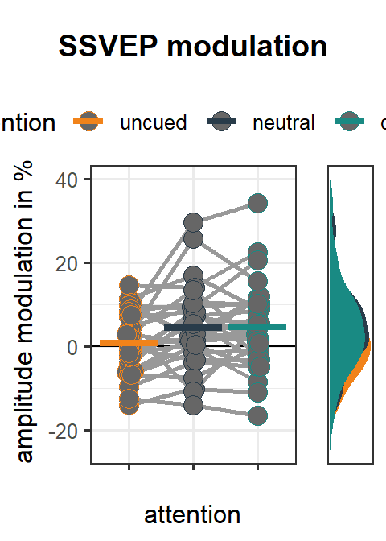

```r
# str(DATA.In_longer)
dat_plot <- DATA.In_longer %>%
  filter(post_hit == "hit") %>%
  dplyr::select(subject, trialnumber, post_event_pos_label, signal, time, amplitude, attention)%>%
  group_by(subject, post_event_pos_label, signal, time, attention) %>%
  dplyr::summarise(amplitude=mean(amplitude))%>%
  ungroup()%>%
  pivot_wider(names_from = "time", values_from = amplitude) %>%
  mutate(pre_to_post = ((`[500 1500]ms`/`[-1000 0]ms`)-1)*100)%>%
  # mutate(pre_to_post = `[500 1500]ms`-`[-1000 0]ms`)%>%
  pivot_longer(`[-1000 0]ms`:pre_to_post, names_to = "time", values_to = "amplitude") %>%
  group_by(subject, signal, time, attention) %>%
  dplyr::summarise(amplitude=mean(amplitude))%>%
  ungroup()%>%
  filter(time == "pre_to_post")
dat2plot <- dat_plot %>%
  filter(signal == "SSVEP")

### for saving with alpha = 1
#induced baseline corrected####

theme_set(theme_bw())
plot1 <- ggplot(dat2plot, aes(x = attention, y = amplitude, fill = attention)) +
  geom_hline(yintercept=0, show.legend = FALSE) +
  geom_line(aes(group = interaction(subject,time)),colour = "grey60",alpha = 1,size =1) +
  geom_beeswarm(aes(color = attention, x = attention,
                    group = attention), cex=1.5, size = 4,alpha=1,fill="grey40",shape=21)+
  # geom_point(aes(color = attention, x = interaction(time,condition),
  #                   group = attention), size = 4,alpha=0.4)+
  stat_summary(fun.y=mean, aes(ymin=..y.., ymax=..y.., color =attention), geom='errorbar', width=0.9, size=1.5) +
  scale_x_discrete("attention", breaks=waiver(), labels = rep(c(""),1,3)) +
  # theme(legend.position="bottom") +
  ylab(expression(paste("amplitude modulation in %")))+
  # labs(title=sprintf("SSVEP modulation | evoked"),
  #      subtitle="collapsed across frequencies")+
  scale_fill_manual(values=c("#F1831A", "#293C4A", "#198A83"))+
  # scale_fill_manual(values=c("#FFC876", "#162B3F", "#1A776F"))+
  # scale_fill_brewer(palette = "Dark2")+
  scale_color_manual(values=c("#F1831A", "#293C4A", "#198A83"))+
  # scale_color_manual(values=c("#FFC876", "#162B3F", "#1A776F"))+
  # scale_color_brewer(palette = "Dark2")+
  theme(legend.position="none")+
  # scale_y_continuous(limits=c(-60, 140))
  scale_y_continuous(limits=c(-25, 40))


plot2 <- ggplot(dat2plot, aes(y = amplitude, fill = attention, x = 1)) +
  geom_flat_violin(aes(fill = attention),position = position_nudge(x = .1, y = 0), adjust = 1, trim = FALSE, alpha = 1, colour = NA)+
  scale_fill_manual(values=c("#F1831A", "#293C4A", "#198A83"))+
  # scale_fill_manual(values=c("#FFC876", "#162B3F", "#1A776F"))+
  # scale_fill_brewer(palette = "Dark2")+
  scale_color_manual(values=c("#F1831A", "#293C4A", "#198A83"))+
  # scale_color_manual(values=c("#FFC876", "#162B3F", "#1A776F"))+
  # scale_color_brewer(palette = "Dark2")+
  theme(axis.title.y=element_blank(),
        axis.text.y=element_blank(),
        axis.ticks.y=element_blank())+
  theme(axis.title.x=element_blank(),
        axis.text.x=element_blank(),
        axis.ticks.x=element_blank())+
  theme(panel.grid.major = element_blank(), panel.grid.minor = element_blank())+
  # scale_y_continuous(limits=c(-60, 140))
  scale_y_continuous(limits=c(-25, 40))



plotttitle <- ggdraw() + draw_label("SSVEP modulation", fontface='bold')
plotplots <- ggarrange(plot1, plot2,ncol = 2,common.legend = TRUE,align = "h", widths=c(4,1))
saveplot <- ggarrange(plotttitle, plotplots, nrow = 2, heights=c(0.2, 1))
# ggsave(filename = "figures/SSVEP_Mod.eps", width = 2.5, height = 3.5,
#        plot = print(saveplot))
print(saveplot)
```

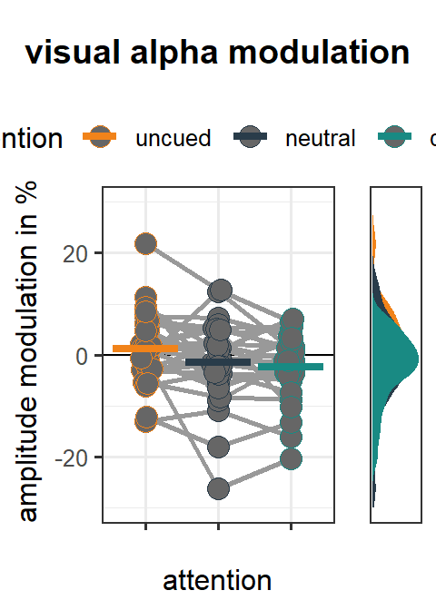

```r
dat2plot <- dat_plot %>%
  filter(signal == "visualAlpha")

### for saving with alpha = 1
#induced baseline corrected####
theme_set(theme_bw())
plot1 <- ggplot(dat2plot, aes(x = attention, y = amplitude, fill = attention)) +
  geom_hline(yintercept=0, show.legend = FALSE) +
  geom_line(aes(group = interaction(subject,time)),colour = "grey60",alpha = 1,size =1) +
  geom_beeswarm(aes(color = attention, x = attention,
                    group = attention), cex=1.5, size = 4,alpha=1,fill="grey40",shape=21)+
  # geom_point(aes(color = attention, x = interaction(time,condition),
  #                   group = attention), size = 4,alpha=0.4)+
  stat_summary(fun.y=mean, aes(ymin=..y.., ymax=..y.., color =attention), geom='errorbar', width=0.9, size=1.5) +
  scale_x_discrete("attention", breaks=waiver(), labels = rep(c(""),1,3)) +
  # theme(legend.position="bottom") +
  ylab(expression(paste("amplitude modulation in %")))+
  # labs(title=sprintf("SSVEP modulation | evoked"),
  #      subtitle="collapsed across frequencies")+
  scale_fill_manual(values=c("#F1831A", "#293C4A", "#198A83"))+
  # scale_fill_manual(values=c("#FFC876", "#162B3F", "#1A776F"))+
  # scale_fill_brewer(palette = "Dark2")+
  scale_color_manual(values=c("#F1831A", "#293C4A", "#198A83"))+
  # scale_color_manual(values=c("#FFC876", "#162B3F", "#1A776F"))+
  # scale_color_brewer(palette = "Dark2")+
  theme(legend.position="none")+
  # scale_y_continuous(limits=c(-60, 140))
  scale_y_continuous(limits=c(-30, 30))


plot2 <- ggplot(dat2plot, aes(y = amplitude, fill = attention, x = 1)) +
  geom_flat_violin(aes(fill = attention),position = position_nudge(x = .1, y = 0), adjust = 1, trim = FALSE, alpha = 1, colour = NA)+
  scale_fill_manual(values=c("#F1831A", "#293C4A", "#198A83"))+
  # scale_fill_manual(values=c("#FFC876", "#162B3F", "#1A776F"))+
  # scale_fill_brewer(palette = "Dark2")+
  scale_color_manual(values=c("#F1831A", "#293C4A", "#198A83"))+
  # scale_color_manual(values=c("#FFC876", "#162B3F", "#1A776F"))+
  # scale_color_brewer(palette = "Dark2")+
  theme(axis.title.y=element_blank(),
        axis.text.y=element_blank(),
        axis.ticks.y=element_blank())+
  theme(axis.title.x=element_blank(),
        axis.text.x=element_blank(),
        axis.ticks.x=element_blank())+
  theme(panel.grid.major = element_blank(), panel.grid.minor = element_blank())+
  # scale_y_continuous(limits=c(-60, 140))
  scale_y_continuous(limits=c(-30, 30))



plotttitle <- ggdraw() + draw_label("visual alpha modulation", fontface='bold')
plotplots <- ggarrange(plot1, plot2,ncol = 2,common.legend = TRUE,align = "h", widths=c(4,1))
saveplot <- ggarrange(plotttitle, plotplots, nrow = 2, heights=c(0.2, 1))
# ggsave(filename = "figures/VisAlpha_Mod.eps", width = 2.5, height = 3.5,
#        plot = print(saveplot))
print(saveplot)
```

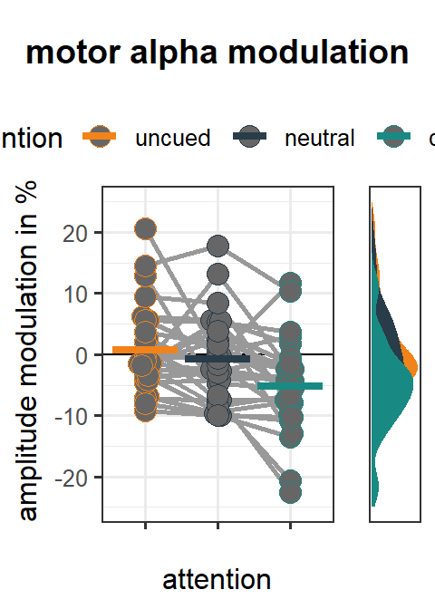

```r
dat2plot <- dat_plot %>%
  filter(signal == "motorAlpha")

### for saving with alpha = 1
#induced baseline corrected####
theme_set(theme_bw())
plot1 <- ggplot(dat2plot, aes(x = attention, y = amplitude, fill = attention)) +
  geom_hline(yintercept=0, show.legend = FALSE) +
  geom_line(aes(group = interaction(subject,time)),colour = "grey60",alpha = 1,size =1) +
  geom_beeswarm(aes(color = attention, x = attention,
                    group = attention), cex=1.5, size = 4,alpha=1,fill="grey40",shape=21)+
  # geom_point(aes(color = attention, x = interaction(time,condition),
  #                   group = attention), size = 4,alpha=0.4)+
  stat_summary(fun.y=mean, aes(ymin=..y.., ymax=..y.., color =attention), geom='errorbar', width=0.9, size=1.5) +
  scale_x_discrete("attention", breaks=waiver(), labels = rep(c(""),1,3)) +
  # theme(legend.position="bottom") +
  ylab(expression(paste("amplitude modulation in %")))+
  # labs(title=sprintf("SSVEP modulation | evoked"),
  #      subtitle="collapsed across frequencies")+
  scale_fill_manual(values=c("#F1831A", "#293C4A", "#198A83"))+
  # scale_fill_manual(values=c("#FFC876", "#162B3F", "#1A776F"))+
  # scale_fill_brewer(palette = "Dark2")+
  scale_color_manual(values=c("#F1831A", "#293C4A", "#198A83"))+
  # scale_color_manual(values=c("#FFC876", "#162B3F", "#1A776F"))+
  # scale_color_brewer(palette = "Dark2")+
  theme(legend.position="none")+
  # scale_y_continuous(limits=c(-60, 140))
  scale_y_continuous(limits=c(-25, 25))


plot2 <- ggplot(dat2plot, aes(y = amplitude, fill = attention, x = 1)) +
  geom_flat_violin(aes(fill = attention),position = position_nudge(x = .1, y = 0), adjust = 1, trim = FALSE, alpha = 1, colour = NA)+
  scale_fill_manual(values=c("#F1831A", "#293C4A", "#198A83"))+
  # scale_fill_manual(values=c("#FFC876", "#162B3F", "#1A776F"))+
  # scale_fill_brewer(palette = "Dark2")+
  scale_color_manual(values=c("#F1831A", "#293C4A", "#198A83"))+
  # scale_color_manual(values=c("#FFC876", "#162B3F", "#1A776F"))+
  # scale_color_brewer(palette = "Dark2")+
  theme(axis.title.y=element_blank(),
        axis.text.y=element_blank(),
        axis.ticks.y=element_blank())+
  theme(axis.title.x=element_blank(),
        axis.text.x=element_blank(),
        axis.ticks.x=element_blank())+
  theme(panel.grid.major = element_blank(), panel.grid.minor = element_blank())+
  # scale_y_continuous(limits=c(-60, 140))
  scale_y_continuous(limits=c(-25, 25))



# cowplot::plot_grid(plot1, plot2, plot3, ncol = 3,labels = "AUTO")
plotttitle <- ggdraw() + draw_label("motor alpha modulation", fontface='bold')
plotplots <- ggarrange(plot1, plot2,ncol = 2,common.legend = TRUE,align = "h", widths=c(4,1))
saveplot <- ggarrange(plotttitle, plotplots, nrow = 2, heights=c(0.2, 1))
print(saveplot)
```

```r
# ggsave(filename = "figures/MotorAlpha_Mod.eps", width = 2.5, height = 3.5,
#        plot = print(saveplot))
```

## decriptive data

### electrophysiological measures

validity

average electrophysiological measures

| signal | cue_validity_label | pos_rel_target | M | SD |
| --- | --- | --- | --- | --- |
| SSVEP | invalid | contra_nontarget | 5.362735 | 13.011 |
| SSVEP | invalid | contra_target | 2.070415 | 9.183 |
| SSVEP | neutral | contra_nontarget | 3.587750 | 11.528 |
| SSVEP | neutral | contra_target | 6.568053 | 9.754 |
| SSVEP | valid | contra_nontarget | 1.029502 | 7.770 |
| SSVEP | valid | contra_target | 5.001276 | 10.647 |
| motorAlpha | invalid | contra_nontarget | -5.767622 | 9.656 |
| motorAlpha | invalid | contra_target | 0.197405 | 7.402 |
| motorAlpha | neutral | contra_nontarget | -0.599796 | 7.061 |
| motorAlpha | neutral | contra_target | -0.883747 | 8.545 |
| motorAlpha | valid | contra_nontarget | 1.001945 | 7.361 |
| motorAlpha | valid | contra_target | -4.922634 | 7.386 |
| visualAlpha | invalid | contra_nontarget | -1.744584 | 7.374 |
| visualAlpha | invalid | contra_target | 1.732357 | 6.208 |
| visualAlpha | neutral | contra_nontarget | -1.497993 | 8.933 |
| visualAlpha | neutral | contra_target | -1.331550 | 7.910 |
| visualAlpha | valid | contra_nontarget | 1.034433 | 7.681 |
| visualAlpha | valid | contra_target | -2.412490 | 6.789 |

average electrophysiological measures

| signal | attention | M | SD |
| --- | --- | --- | --- |
| SSVEP | uncued | 0.699 | 7.43293 |
| SSVEP | neutral | 4.426 | 10.05035 |
| SSVEP | cued | 4.558 | 10.67430 |
| motorAlpha | uncued | 0.783 | 7.05694 |
| motorAlpha | neutral | -0.761 | 7.11496 |
| motorAlpha | cued | -5.185 | 7.61981 |
| visualAlpha | uncued | 1.170 | 7.16389 |
| visualAlpha | neutral | -1.431 | 8.29730 |
| visualAlpha | cued | -2.297 | 6.69420 |

## tests

test of general model

### ANOVA electrophysiological measures

ANOVA_RM for electrophysiological measures: meas ~ ATTENTION(cued, neutral, uncued)

```r
#ANOVAe
DATA.In_longer %>%
  filter(post_hit == "hit") %>%
  dplyr::select(subject, trialnumber, post_event_pos_label, signal, time, amplitude, attention)%>%
  group_by(subject, post_event_pos_label, signal, time, attention) %>%
  dplyr::summarise(amplitude=mean(amplitude))%>%
  ungroup()%>%
  pivot_wider(names_from = "time", values_from = amplitude) %>%
  mutate(pre_to_post = ((`[500 1500]ms`/`[-1000 0]ms`)-1)*100)%>%
  # mutate(pre_to_post = `[500 1500]ms`-`[-1000 0]ms`)%>%
  pivot_longer(`[-1000 0]ms`:pre_to_post, names_to = "time", values_to = "amplitude") %>%
  group_by(subject, signal, time, attention) %>%
  dplyr::summarise(amplitude=mean(amplitude))%>%
  ungroup()%>%
  filter(time == "pre_to_post")%>%
  group_by(signal)%>%
  nest() %>%
  mutate(stats= purrr::map(data, ~broom::tidy(
    anova(aov_ez(id="subject", dv = "amplitude", data = ., within = "attention"))
  ))) %>%
  dplyr::select(-data) %>%
  unnest()%>%
  mutate(
    `p.value` = cell_spec(ifelse(round(`p.value`,4)<.001,"< .001",round(`p.value`,4)),
                        color = ifelse(is.nan(`p.value`),"blue", ifelse(`p.value` < .05, "green", "red")),
                        bold = ifelse(is.nan(`p.value`),F, ifelse(`p.value` < .05, T,F)),
                        align = "center")
  ) %>%
  dplyr::select(signal, term, `num.Df`, `den.Df`, MSE, `statistic`, ges, `p.value`) %>%
  kable(escape = F, digits = c(3,3,3,3,3,3,3,3,3), caption = c("repeated measures ANOVA ")) %>%
  kable_styling("striped", full_width = T, bootstrap_options = c("striped", "hover", "condensed", "responsive",font_size = 8))
```

repeated measures ANOVA

| signal | term | num.Df | den.Df | MSE | statistic | ges | p.value |
| --- | --- | --- | --- | --- | --- | --- | --- |
| SSVEP | attention | 1.944 | 52.475 | 28.644 | 4.829 | 0.036 | 0.0125 |
| motorAlpha | attention | 1.981 | 53.497 | 27.417 | 9.892 | 0.112 | < .001 |
| visualAlpha | attention | 1.421 | 38.374 | 27.313 | 4.697 | 0.039 | 0.0247 |

### Post-hoc t-Tests electrophysiological measures (cued vs neutral vs uncued)

```
##  contrast           effect.size    SE df lower.CL upper.CL
##  (uncued - neutral)     -0.3928 0.158 54   -0.709  -0.0762
##  (uncued - cued)        -0.4066 0.159 54   -0.725  -0.0888
##  (neutral - cued)       -0.0139 0.149 54   -0.312   0.2840
##
## sigma used for effect sizes: 9.49
## Confidence level used: 0.95
```

estimated marginal means | by att. focus | dv = SSVEP

| attention | emmean | SE | df | lower.CL | upper.CL |
| --- | --- | --- | --- | --- | --- |
| uncued | 0.699 | 1.794 | 41.436 | -2.922 | 4.320 |
| neutral | 4.426 | 1.794 | 41.436 | 0.805 | 8.047 |
| cued | 4.558 | 1.794 | 41.436 | 0.937 | 8.179 |

contrasts for estimated marginal means | by att. focus | dv = SSVEP | corrected: Holm

| contrast | estimate | SE | df | t.ratio | p.value | CohensD | lowCI | highCI |
| --- | --- | --- | --- | --- | --- | --- | --- | --- |
| uncued - neutral | -3.728 | 1.41 | 54 | -2.644 | 0.0251 | -0.393 | -0.709 | -0.076 |
| uncued - cued | -3.859 | 1.41 | 54 | -2.737 | 0.0251 | -0.407 | -0.725 | -0.089 |
| neutral - cued | -0.132 | 1.41 | 54 | -0.093 | 0.926 | -0.014 | -0.312 | 0.284 |

estimated marginal means | by att. focus | dv = visual alpha

| attention | emmean | SE | df | lower.CL | upper.CL |
| --- | --- | --- | --- | --- | --- |
| uncued | 1.170 | 1.401 | 44.085 | -1.654 | 3.994 |
| neutral | -1.431 | 1.401 | 44.085 | -4.255 | 1.394 |
| cued | -2.297 | 1.401 | 44.085 | -5.122 | 0.527 |

contrasts for estimated marginal means | by att. focus | dv = visual alpha | corrected: Holm

| contrast | estimate | SE | df | t.ratio | p.value | CohensD | lowCI | highCI |
| --- | --- | --- | --- | --- | --- | --- | --- | --- |
| uncued - neutral | 2.601 | 1.177 | 54 | 2.209 | 0.0629 | 0.351 | 0.018 | 0.683 |
| uncued - cued | 3.467 | 1.177 | 54 | 2.945 | 0.0143 | 0.468 | 0.125 | 0.811 |
| neutral - cued | 0.867 | 1.177 | 54 | 0.736 | 0.4649 | 0.117 | -0.203 | 0.437 |

estimated marginal means | by att. focus | dv = motor alpha

| attention | emmean | SE | df | lower.CL | upper.CL |
| --- | --- | --- | --- | --- | --- |
| uncued | 0.783 | 1.374 | 55.023 | -1.970 | 3.535 |
| neutral | -0.761 | 1.374 | 55.023 | -3.513 | 1.992 |
| cued | -5.185 | 1.374 | 55.023 | -7.938 | -2.433 |

contrasts for estimated marginal means | by att. focus | dv = motor alpha | corrected: Holm

| contrast | estimate | SE | df | t.ratio | p.value | CohensD | lowCI | highCI |
| --- | --- | --- | --- | --- | --- | --- | --- | --- |
| uncued - neutral | 1.543 | 1.393 | 54 | 1.108 | 0.2728 | 0.212 | -0.176 | 0.601 |
| uncued - cued | 5.968 | 1.393 | 54 | 4.285 | < .001 | 0.821 | 0.376 | 1.266 |
| neutral - cued | 4.424 | 1.393 | 54 | 3.177 | 0.0049 | 0.609 | 0.190 | 1.027 |

contrasts for estimated marginal means | against zero | dv = SSVEP modulation | corrected: Holm

| contrast | estimate | SE | df | t.ratio | p.value | CohensD | lowCI | highCI |
| --- | --- | --- | --- | --- | --- | --- | --- | --- |
| uncued | 0.699 | 1.794 | 41.436 | 0.390 | 0.6988 | 0.074 | -0.308 | 0.456 |
| neutral | 4.426 | 1.794 | 41.436 | 2.468 | 0.0446 | 0.466 | 0.064 | 0.869 |
| cued | 4.558 | 1.794 | 41.436 | 2.541 | 0.0446 | 0.480 | 0.077 | 0.884 |

contrasts for estimated marginal means | against zero | dv = vis alpha modulation | corrected: Holm

| contrast | estimate | SE | df | t.ratio | p.value | CohensD | lowCI | highCI |
| --- | --- | --- | --- | --- | --- | --- | --- | --- |
| uncued | 1.170 | 1.401 | 44.085 | 0.835 | 0.6258 | 0.158 | -0.226 | 0.541 |
| neutral | -1.431 | 1.401 | 44.085 | -1.021 | 0.6258 | -0.193 | -0.577 | 0.192 |
| cued | -2.297 | 1.401 | 44.085 | -1.639 | 0.3248 | -0.310 | -0.700 | 0.080 |

contrasts for estimated marginal means | against zero | dv = motor alpha modulation | corrected: Holm

| contrast | estimate | SE | df | t.ratio | p.value | CohensD | lowCI | highCI |
| --- | --- | --- | --- | --- | --- | --- | --- | --- |
| uncued | 0.783 | 1.374 | 55.023 | 0.570 | 1 | 0.108 | -0.272 | 0.488 |
| neutral | -0.761 | 1.374 | 55.023 | -0.554 | 1 | -0.105 | -0.484 | 0.275 |
| cued | -5.185 | 1.374 | 55.023 | -3.775 | 0.0012 | -0.713 | -1.139 | -0.288 |